# Fasores

## Introducción

Un fasor es una representación de una oscilación a través de un número complejo. En física e ingeniería,un vector de fase o fasor, es una representación de una función sinusoidal con una amplitud (A), frecuencia ($\omega$), fase ($\theta$) y es invariente en el tiempo.

Segun la identidad de Euler se tiene

seleccionando únicamente la parte real

\begin{align} A\cdot \cos(\omega t + \theta) &= \operatorname{Re} \left\{ A\cdot e^{i(\omega t + \theta)}\right\} \\ &= \operatorname{Re} \left\{ A e^{i\theta} \cdot e^{i\omega t}\right\}. \end{align}

El termino fasor se puede referir a $Ae^{i\theta}e^{i \omega t} $ o simplemente a la constante compleja, $A e^{i\theta}\, $. Es importante notar que

$$ \cos(\omega t)= \sin (\omega t + 90º)=\operatorname{Re} \left\{ A e^{i\theta+\frac{\pi}{2}} \cdot e^{i\omega t}\right\}, $$ por lo que se puede afirmar que $A\cos(\omega t+ \theta)$ puede representar a cualquier señal oscilatoria periodica simple.

## Derivación e Integración del fasor

La derivada en tiempo de un fasor es

\begin{align*} \operatorname{Re}\left\{\frac{d}{d t}(A e^{i\theta} \cdot e^{i\omega t})\right\} &= \operatorname{Re}\{A e^{i\theta} \cdot i\omega e^{i\omega t}\} \\ &= \operatorname{Re}\{A e^{i\theta} \cdot e^{i\pi/2} \omega e^{i\omega t}\} \\ &= \operatorname{Re}\{\omega A e^{i(\theta + \pi/2)} \cdot e^{i\omega t}\} \\ &= \omega A\cdot \cos(\omega t + \theta + \pi/2) \end{align*}

Por lo tanto, en la representación fasorial la derivación en tiempo de una señal senoidal es soloamente multiplar el fasor por la constante,

\begin{equation} i \omega = (e^{i\pi/2} \cdot \omega)\,. \end{equation}

De forma similar, **integrar en tiempo** un fasor corresponde a la multiplicación por la constante

\begin{equation} \frac{1}{i\omega} = \frac{e^{-i\pi/2}}{\omega}. \end{equation}

El factor dependiendte del tiempo, $e^{i\omega t}\,,$ no es afectado.

## Serie de Fourier

Una serie de Fourier es una *serie infinita* que converge puntualmente a una función periódica y continua a trozos (o por partes) Si $f(t)$ es una función (o señal) periódica y su período es $T$, la serie de Fourier asociada a $f(t)$ es:

\begin{equation} f(t) \sim \frac{a_0}{2} + \sum_{n=1}^\infty\left[a_n\cos\frac{2n\pi}{T}t + b_n\sin\frac{2n\pi}{T}t\right] \end{equation}

Donde $a_0$, $a_n$ y $b_n$ son los coeficientes de Fourier que toman los valores:

$$ a_0 = \frac{2}{T} \int \limits_{-T/2}^{T/2} f(t) dt, \qquad a_n = \frac{2}{T} \int_{-T/2}^{T/2} f(t) \cos \left( \frac{2n \pi}{T} t \right) dt, \qquad b_n=\frac{2}{T} \int_{-T/2}^{T/2} f(t) \sin \left(\frac{2n\pi}{T}t\right) dt. $$

En ocasiones es más útil conocer la amplitud y la fase en términos cosinusoidales en lugar de amplitudes cosinusoidales y sinusoidal. Otra forma de expresar la compleja forma de la serie de Fourier es:

\begin{equation} f(t)=A_0+\sum_{n=1}^{\infty} A_{n}\,\cos({{\omega_n}t}-\theta_n) \end{equation}

donde

\begin{align*} A_0=&\frac{a_0}{2} \\ A_n=&\sqrt{a^2_n+b^2_n} \\ \theta_n=&\tan^{-1}\frac{b_n}{a_n} \end{align*}

Por la identidad de Euler, las fórmulas de arriba pueden expresarse también en su forma compleja:

\begin{equation} f(t) \sim \sum_{n=-\infty}^{\infty} c_{n}\,e^{2\pi i\frac{n}{T}t}. \end{equation}

Los coeficientes ahora serían: $$ c_n=\frac{1}{T}\int_{-T/2}^{T/2} f(t)e^{-2\pi i\frac {n}{T}t}\,dt. $$

### Ejemplo

Considere

$$ f(t)=\cos(2\pi20t)+2\sin(2\pi10t)+1.5\cos(2\pi40t) $$

$$ C_{n}=\frac{1}{N}\sum_{i=0}^{i=N-1}y(i)e^{-2\pi i\frac {nt}{T}}. $$

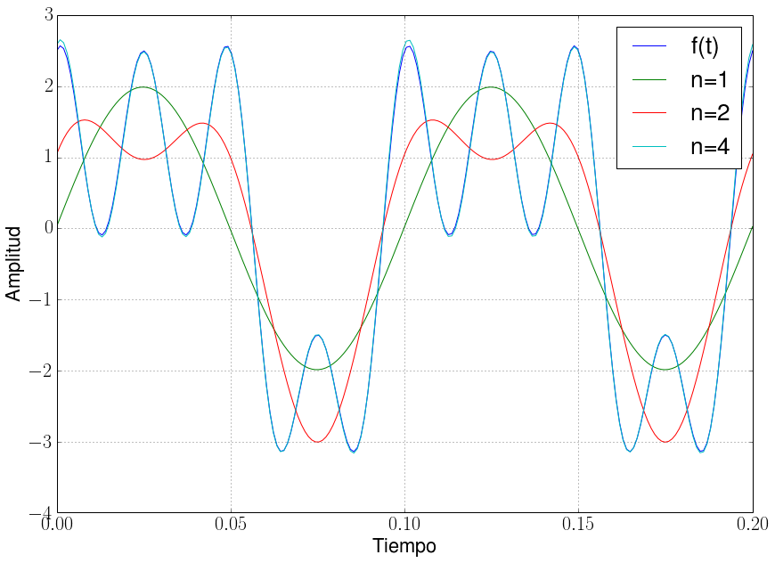

```python
import numpy as np
import matplotlib
%matplotlib inline
matplotlib.rcParams.update({'font.size': 22,'text.usetex': True})
import matplotlib.pyplot as plt

time=np.linspace(0,0.2,200)
y=np.cos(2*np.pi*20*time)+(2*np.sin(2*np.pi*10*time))+(1.5*np.cos(2*np.pi*40*time))
period=1/10

def cn(n):
   c = y*np.exp(-1j*2*n*np.pi*time/period)
   return c.sum()/c.size

def f(x, Nh):
   f = np.array([2*cn(i)*np.exp(1j*2*i*np.pi*x/period) for i in range(1,Nh+1)])
   return f.sum()


y2 = np.array([f(t,1).real for t in time])
y3 = np.array([f(t,2).real for t in time])
y4 = np.array([f(t,4).real for t in time])
plt.figure(figsize=(14,10), dpi=150)
plt.plot(time,y,time,y2,time,y3,time,y4)
plt.grid('on')
plt.xlabel('Tiempo')
plt.ylabel('Amplitud')
plt.legend(['f(t)','n=1','n=2','n=4'])
plt.show()
```

# Analisis de circuitos con fasores

Consider el circuito que se muestra en la siguiente figura

[figure not shown]

utilizando las leyes de krichof se tiene que $$ i_{R}=i_{C} $$ utilizando las ley de ohm y las propiedades del capcitor de tiene $$ \frac{V_{i}(t)-V_{C}(t)}{R}=C\frac{dV_{C}(t)}{dt} $$ despejando se tiene

\begin{equation}\label{eq:cirrc} C\frac{dV_{C}(t)}{dt}+\frac{V_{C}(t)}{R}=\frac{V_{i}(t)}{R} \end{equation}

Considerando $V_{i}(t)$ como

$$ V_i(t) = V_P\cdot \cos(\omega t + \theta), $$

si se considera su representación en fasores

\begin{align*} V_i(t) =& \operatorname{Re} \{V_i \cdot e^{i\omega t}\} \\ V_C(t) =& \operatorname{Re} \{V_c \cdot e^{i\omega t}\} \end{align*}

donde el fasor $V_i = V_P e^{i\theta},$ y el fasor $V_c$ es desconocido y es la variable a encontrar. En notación fasorial la expresión \eqref{eq:cirrc} es

$$ i \omega V_c + \frac{1}{RC} V_c = \frac{1}{RC}V_i $$ Resolviendo para el fasor de $V_{C}$ se tiene

$$ V_c = \frac{1}{1 + i \omega RC} \cdot (V_i) = \frac{1-i\omega R C}{1+(\omega R C)^2} \cdot (V_P e^{i\theta}) $$

El factor que multiplica al fasor $V_i$ representa la diferencia en amplitud y fase de $V_C(t)$ respecto a $V_{i}(t)$. Sin embargo, la representación de dicho factor en la expresión anterior resulta complicada de resolver como fasor, por lo que si se considera su representación polar se tiene

$$ \frac{1}{\sqrt{1 + (\omega RC)^2}}\cdot e^{-i \phi(\omega)} $$ donde $$ \phi(\omega) = \arctan(\omega RC). $$ Considerando las expresiones anteriores se tiene

\begin{equation} V_C(t) = \frac{1}{\sqrt{1 + (\omega RC)^2}}\cdot V_P \cos(\omega t + \theta- \phi(\omega)) \end{equation}

Considerando la ganancia del sitema definida como la razón entre la señal de salida y la señal de entrada, en el circuito RC se tiene que la ganacia es

\begin{equation} \frac{V_{C}}{V_{i}}=\frac{1}{\sqrt{1 + (\omega RC)^2}}\cdot e^{-i \phi(\omega)} \end{equation}

de la expresión anterior se tiene que la ganacia nos indica que $V_C=V_i$ cuando $\omega=0$, y teoricamente $V_C=0$ cuando $\omega=\infty$

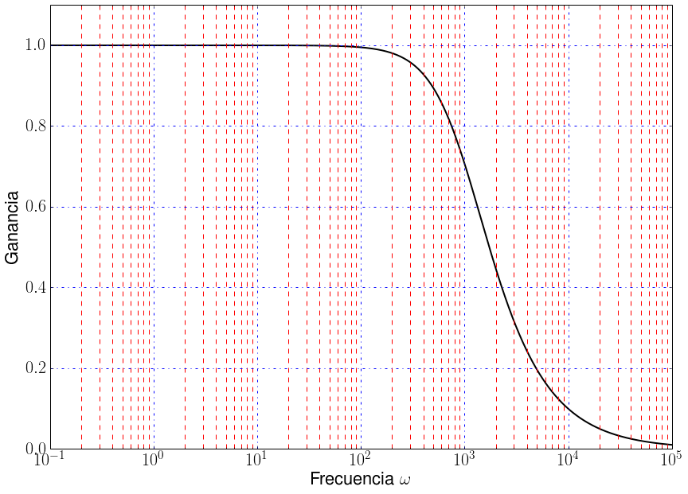

```python
w=linspace(0.1,100000,100000)
R=1000
C=0.000001
A=1/(np.sqrt(1+np.power(R*C*w,2)))
plt.figure(figsize=(14,10), dpi=150)
plt.plot(w,A,color='k',linewidth=2)
plt.xscale('log')
plt.grid(b=True, which='major', color='b', linestyle='-.',linewidth=1)
plt.grid(b=True, which='minor', color='r', linestyle='--',linewidth=1)
plt.xlabel('Frecuencia $\omega$')
plt.ylabel('Ganancia')
plt.ylim([0,1.1])
plt.show()
```

## Decibel

El decibelio (dB) es una unidad logarítmica utilizada para expresar la relación entre dos valores de una cantidad física, a menudo potencia o intensidad. Una de estas cantidades es a menudo el valor de referencia, y en este caso el decibelio se puede utilizar para expresar el nivel absoluto de la cantidad física. El decibel también se utiliza comúnmente como una medida de la ganancia o de atenuación, la relación de entrada y salida de potencias de un sistema, o de factores individuales que contribuyen a este tipo de coeficientes.

$$ L_\mathrm{dB} = 10 \log_{10} \bigg(\frac{P_1}{P_0}\bigg) \, $$

En circuitos eléctricos, la potencia disipada es normalmente proporcional al cuadrado del voltaje o corriente cuando la impedancia se mantiene constante. Tomando el voltaje como un ejemplo, esto conduce a la ecuación:

$$ G_\mathrm{dB} =20 \log_{10} \left (\frac{V_o}{V_i} \right ) \quad \mathrm \quad $$

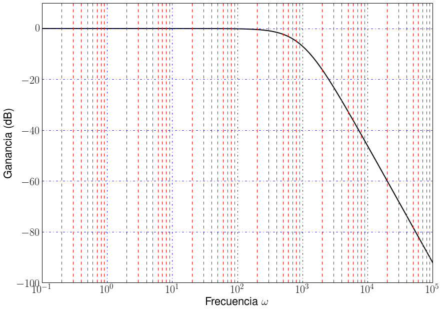

```python
Gb=20*np.log(A)
plt.figure(figsize=(14,10), dpi=150)
plt.plot(w,Gb,color='k',linewidth=2)
plt.xscale('log')
plt.grid(b=True, which='major', color='b', linestyle='-.',linewidth=1)
plt.grid(b=True, which='minor', color='r', linestyle='--',linewidth=1)
plt.ylim([-100,10])
plt.xlabel('Frecuencia $\omega$')
plt.ylabel('Ganancia (dB)')
plt.show()
```

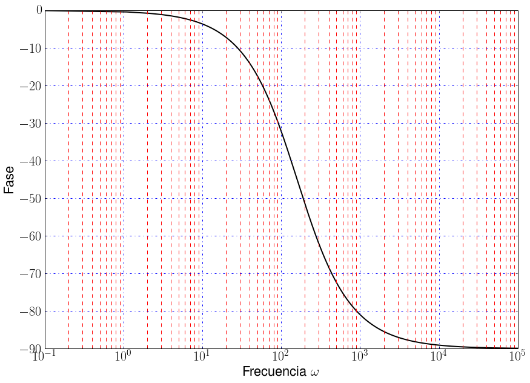

```python
phase=-np.arctan(w*2*np.pi*R*C)*57.2957795
plt.figure(figsize=(14,10), dpi=150)
plt.plot(w,phase,color='k',linewidth=2)
plt.xscale('log')
plt.grid(b=True, which='major', color='b', linestyle='-.',linewidth=1)
plt.grid(b=True, which='minor', color='r', linestyle='--',linewidth=1)
#plt.ylim([-100,10])
plt.xlabel('Frecuencia $\omega$')
plt.ylabel('Fase')
plt.show()
```

Pagina escrita en Ipython por *Manuel Moisés Miranda Velasco*